# R Notebook

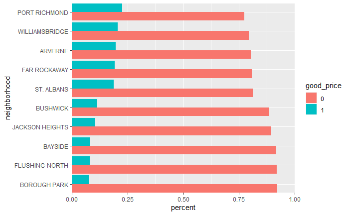

```r
nyc_prop_for_EDA %>%
  mutate(., neighborhood = ordered(neighborhood, levels =
            c("BOROUGH PARK", "FLUSHING-NORTH", "BAYSIDE", "JACKSON HEIGHTS", "BUSHWICK", "ST. ALBANS", "FAR ROCKAWAY", "ARVERNE", "WILLIAMSBRIDGE", "PORT RICHMOND"))) %>%
  group_by(., good_price, neighborhood) %>%
  summarise(., amount = n()) %>%
  group_by(neighborhood, .drop = TRUE) %>%
  summarise(., good_price = good_price, amount = amount, percent = amount/sum(amount)) %>%
  filter(., amount > 2) %>% head(20) %>%
  ggplot() + geom_col(aes(x = neighborhood, y = percent, fill = good_price), position = "dodge")  +
  coord_flip(ylim = c(0,1), expand = FALSE)
```

```r
### building_class_at_present

nyc_prop_for_EDA %>%
  group_by(., good_price, building_class_at_present) %>%
  summarise(., amount = n()) %>%
  pivot_wider(., names_from = good_price, values_from = amount) %>%
  select(., building_class_at_present, bad_price = "0", good_price = "1") %>%
  mutate(., ratio_gp = good_price / bad_price) %>%
  arrange(., desc(ratio_gp))
```

| building_class_at_present | bad_price | good_price | ratio_gp |
| --- | --- | --- | --- |
| A9 | 174 | 33 | 0.18965517 |
| B3 | 723 | 137 | 0.18948824 |
| B1 | 798 | 145 | 0.18170426 |
| C0 | 544 | 97 | 0.17830882 |
| A1 | 1992 | 335 | 0.16817269 |
| B2 | 869 | 143 | 0.16455696 |
| A2 | 504 | 80 | 0.15873016 |
| A5 | 1281 | 202 | 0.15768931 |
| B9 | 76 | 9 | 0.11842105 |
| A0 | 55 | 5 | 0.09090909 |

[output cut: 1 more lines]

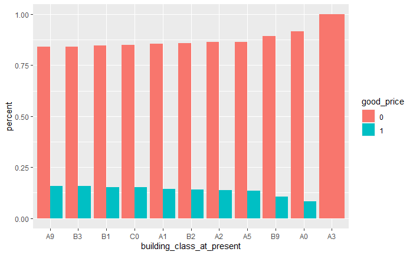

```r
nyc_prop_for_EDA %>%
  mutate(., building_class_at_present = ordered(building_class_at_present, levels =
            c("A9", "B3", "B1", "C0", "A1", "B2", "A2", "A5", "B9", "A0", "A3"))) %>%
  group_by(., good_price, building_class_at_present) %>%
  summarise(., amount = n()) %>%
  group_by(building_class_at_present, .drop = TRUE) %>%
  summarise(., good_price = good_price, amount = amount, percent = amount/sum(amount)) %>%
  ggplot() + geom_col(aes(x = building_class_at_present, y = percent, fill = good_price), position = "dodge")
```

```r
### zip_code

nyc_prop_for_EDA %>%
  group_by(., good_price, zip_code) %>%
  summarise(., amount = n()) %>%
  pivot_wider(., names_from = good_price, values_from = amount) %>%
  select(., zip_code, bad_price = "0", good_price = "1") %>%
  mutate(., ratio_gp = good_price / bad_price) %>%
  arrange(., desc(ratio_gp))
```

| zip_code | bad_price | good_price | ratio_gp |
| --- | --- | --- | --- |
| 11385 | 1 | 1 | 1.00000000 |
| 10303 | 26 | 13 | 0.50000000 |
| 11377 | 6 | 3 | 0.50000000 |
| 10456 | 8 | 3 | 0.37500000 |
| 10306 | 76 | 25 | 0.32894737 |
| 10466 | 52 | 17 | 0.32692308 |
| 10302 | 41 | 13 | 0.31707317 |
| 11691 | 48 | 14 | 0.29166667 |
| 10467 | 18 | 5 | 0.27777778 |
| 11429 | 94 | 25 | 0.26595745 |

[output cut: 82 more lines]

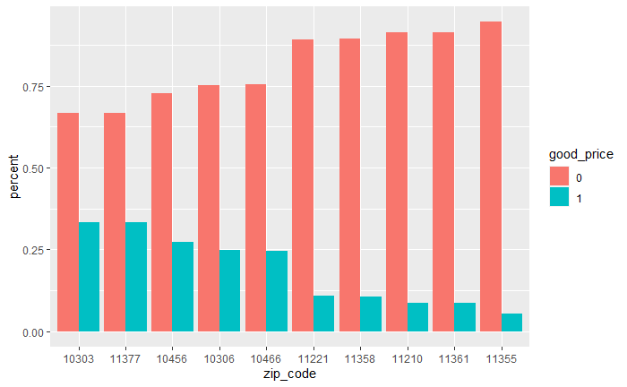

```r
nyc_prop_for_EDA %>%
  mutate(., zip_code = ordered(zip_code,
                               levels = c("10303", "11377", "10456", "10306", "10466",
                                          "11221", "11358", "11210", "11361", "11355"))) %>%
  group_by(., good_price, zip_code) %>%
  summarise(., amount = n()) %>%
  group_by(zip_code, .drop = TRUE) %>%
  summarise(., good_price = good_price, amount = amount, percent = amount/sum(amount)) %>%
  filter(., amount > 2) %>% head(20) %>%
  ggplot() + geom_col(aes(x = zip_code, y = percent, fill = good_price), position = "dodge")
```

```r
# These tables and graphs also show little to no difference in the trend of properties with a good price and properties with a bad price, within each variable. Each variable has a corresponding table and graph.

write.csv(nyc_prop_for_EDA, "./projectApp/nyc_prop_for_EDA.csv")
```

Conclusion: The variables in this dataset does have an influence on the price of a property, but they have no influence on how profitable a property is. I took the variables and took into account the neighborhood and building class (at time of sale) for each variable by dividing the variable by its corresponding average, again, based on its neighborhood and building class. For example, for a property’s sale price, I would find all the properties that was in its neighborhood and building class. Then take the average of their sale price and divide that property’s sale price by the average sale price I found.

I used this method with every grouping of neighborhood and building class and applied it to all the numeric variables of all the properties. I also found the avg standard deviation of the sale price. If a property had a sale price that was below one standard deviation less than its average sale price, it would be considered a good priced property. I separated my dataset this way into 2 groups, good price and bad price.

The tables that were created did a better job in showing where not to by property. The lowest ratio_gp had terrible chances of having a profitable property.

These observations are where there is the most difference between the good price and bad price groups. More analysis is required to know exactly how viable this information is.

If I had more time, I would gather the data from the last few year and see if I get similar results. I believe that it would be different. There were not enough observations within the good price group to get a strong result. I would also scrape housing websites to gather more variables to compare to the good and bad price groups.

I would also like to try doing this a different way. I would calculate the sale price per gross square foot and analyze all the variables based on this.

```r
names(nyc_prop_for_EDA %>% select(., borough, neighborhood, building_class_category, zip_code))
```

```
[1] "borough"                 "neighborhood"            "building_class_category"
[4] "zip_code"
```